# boston_features

```python
from sklearn.datasets import load_wine
import pandas as pd
data=pd.read_csv ("boston_housing.csv")
data
```

|  | crim | zn | indus | chas | nox | rm | age | dis | rad | tax | ptratio | black | lstat | medv |
| --- | --- | --- | --- | --- | --- | --- | --- | --- | --- | --- | --- | --- | --- | --- |
| 0 | 0.00632 | 18.0 | 2.31 | 0 | 0.538 | 6.575 | 65.2 | 4.0900 | 1 | 296.0 | 15.3 | 396.90 | 4.98 | 24.0 |
| 1 | 0.02731 | 0.0 | 7.07 | 0 | 0.469 | 6.421 | 78.9 | 4.9671 | 2 | 242.0 | 17.8 | 396.90 | 9.14 | 21.6 |
| 2 | 0.02729 | 0.0 | 7.07 | 0 | 0.469 | 7.185 | 61.1 | 4.9671 | 2 | 242.0 | 17.8 | 392.83 | 4.03 | 34.7 |
| 3 | 0.03237 | 0.0 | 2.18 | 0 | 0.458 | 6.998 | 45.8 | 6.0622 | 3 | 222.0 | 18.7 | 394.63 | 2.94 | 33.4 |
| 4 | 0.06905 | 0.0 | 2.18 | 0 | 0.458 | 7.147 | 54.2 | 6.0622 | 3 | 222.0 | 18.7 | 396.90 | 5.33 | 36.2 |
| ... | ... | ... | ... | ... | ... | ... | ... | ... | ... | ... | ... | ... | ... | ... |
| 501 | 0.06263 | 0.0 | 11.93 | 0 | 0.573 | 6.593 | 69.1 | 2.4786 | 1 | 273.0 | 21.0 | 391.99 | 9.67 | 22.4 |
| 502 | 0.04527 | 0.0 | 11.93 | 0 | 0.573 | 6.120 | 76.7 | 2.2875 | 1 | 273.0 | 21.0 | 396.90 | 9.08 | 20.6 |
| 503 | 0.06076 | 0.0 | 11.93 | 0 | 0.573 | 6.976 | 91.0 | 2.1675 | 1 | 273.0 | 21.0 | 396.90 | 5.64 | 23.9 |
| 504 | 0.10959 | 0.0 | 11.93 | 0 | 0.573 | 6.794 | 89.3 | 2.3889 | 1 | 273.0 | 21.0 | 393.45 | 6.48 | 22.0 |
| 505 | 0.04741 | 0.0 | 11.93 | 0 | 0.573 | 6.030 | 80.8 | 2.5050 | 1 | 273.0 | 21.0 | 396.90 | 7.88 | 11.9 |

506 rows × 14 columns

```python
# проверка на пропуски
data.info()
```

```
<class 'pandas.core.frame.DataFrame'>
RangeIndex: 506 entries, 0 to 505
Data columns (total 14 columns):
 #   Column   Non-Null Count  Dtype
---  ------   --------------  -----
 0   crim     506 non-null    float64
 1   zn       506 non-null    float64
 2   indus    506 non-null    float64
 3   chas     506 non-null    int64
 4   nox      506 non-null    float64
 5   rm       506 non-null    float64
 6   age      506 non-null    float64
 7   dis      506 non-null    float64
 8   rad      506 non-null    int64
 9   tax      506 non-null    float64
 10  ptratio  506 non-null    float64
 11  black    506 non-null    float64
 12  lstat    506 non-null    float64
 13  medv     506 non-null    float64
dtypes: float64(12), int64(2)
memory usage: 55.5 KB
```

```python
# проверка процента пропущенных значений в каждом признаке
# можно удалить признак, имеющий более 20% пропущенных значений
# в нашем случает таких признаков нет
data.isnull().sum()/len(data) * 100
```

```
crim       0.0
zn         0.0
indus      0.0
chas       0.0
nox        0.0
rm         0.0
age        0.0
dis        0.0
rad        0.0
tax        0.0
ptratio    0.0
black      0.0
lstat      0.0
medv       0.0
dtype: float64
```

### 2. Фильтр с низкой дисперсией

Рассмотрим переменную в нашем наборе данных, где все наблюдения имеют одинаковое значение, скажем 1. Если мы будем использовать эту переменную, как вы думаете, она может улучшить модель, которую мы построим? Ответ - нет, потому что эта переменная будет иметь нулевую дисперсию.

Итак, нам нужно рассчитать дисперсию каждой переменной, которая нам дана. Затем отбросьте переменные, имеющие низкую дисперсию по сравнению с другими переменными в нашем наборе данных. Причина этого, как я упоминал выше, заключается в том, что переменные с низкой дисперсией не влияют на целевую переменную.

```python
# посчитаем дисперсию всех числовых переменных
data.var()
```

```
crim          73.986578
zn           543.936814
indus         47.064442
chas           0.064513
nox            0.013428
rm             0.493671
age          792.358399
dis            4.434015
rad           75.816366
tax        28404.759488
ptratio        4.686989
black       8334.752263
lstat         50.994760
medv          84.586724
dtype: float64
```

```python
numeric = data[['crim','zn','indus','chas','nox','rm','age','dis','rad','tax','ptratio','black','lstat','medv']]
var = numeric.var()
numeric = numeric.columns

variable = [ ]

for i in range(0,len(var)):
    if var[i]>=10:   #setting the threshold as 10%
       variable.append(numeric[i])
```

```python
variable
```

```
['crim', 'zn', 'indus', 'age', 'rad', 'tax', 'black', 'lstat', 'medv']
```

```python
data1=data[variable]
data1
```

|  | crim | zn | indus | age | rad | tax | black | lstat | medv |
| --- | --- | --- | --- | --- | --- | --- | --- | --- | --- |
| 0 | 0.00632 | 18.0 | 2.31 | 65.2 | 1 | 296.0 | 396.90 | 4.98 | 24.0 |
| 1 | 0.02731 | 0.0 | 7.07 | 78.9 | 2 | 242.0 | 396.90 | 9.14 | 21.6 |
| 2 | 0.02729 | 0.0 | 7.07 | 61.1 | 2 | 242.0 | 392.83 | 4.03 | 34.7 |
| 3 | 0.03237 | 0.0 | 2.18 | 45.8 | 3 | 222.0 | 394.63 | 2.94 | 33.4 |
| 4 | 0.06905 | 0.0 | 2.18 | 54.2 | 3 | 222.0 | 396.90 | 5.33 | 36.2 |
| ... | ... | ... | ... | ... | ... | ... | ... | ... | ... |
| 501 | 0.06263 | 0.0 | 11.93 | 69.1 | 1 | 273.0 | 391.99 | 9.67 | 22.4 |
| 502 | 0.04527 | 0.0 | 11.93 | 76.7 | 1 | 273.0 | 396.90 | 9.08 | 20.6 |
| 503 | 0.06076 | 0.0 | 11.93 | 91.0 | 1 | 273.0 | 396.90 | 5.64 | 23.9 |
| 504 | 0.10959 | 0.0 | 11.93 | 89.3 | 1 | 273.0 | 393.45 | 6.48 | 22.0 |
| 505 | 0.04741 | 0.0 | 11.93 | 80.8 | 1 | 273.0 | 396.90 | 7.88 | 11.9 |

506 rows × 9 columns

### 3.3 Высококорреляционный фильтр

Высокая корреляция между двумя переменными означает, что они имеют схожие тенденции и, вероятно, несут одинаковую информацию. Это может резко снизить производительность некоторых моделей (например, моделей линейной и логистической регрессии). Мы можем рассчитать корреляцию между независимыми числовыми переменными, которые по своей природе являются числовыми. Если коэффициент корреляции пересекает определенное пороговое значение, мы можем отбросить одну из переменных (отбрасывание переменной очень субъективно и всегда должно выполняться с учетом предметной области).

Как правило, мы должны оставить те переменные, которые показывают достойную или высокую корреляцию с целевой переменной.

Выполним расчет корреляции.

```python
data1.corr()
```

|  | crim | zn | indus | age | rad | tax | black | lstat | medv |
| --- | --- | --- | --- | --- | --- | --- | --- | --- | --- |
| crim | 1.000000 | -0.200469 | 0.406583 | 0.352734 | 0.625505 | 0.582764 | -0.385064 | 0.455621 | -0.388305 |
| zn | -0.200469 | 1.000000 | -0.533828 | -0.569537 | -0.311948 | -0.314563 | 0.175520 | -0.412995 | 0.360445 |
| indus | 0.406583 | -0.533828 | 1.000000 | 0.644779 | 0.595129 | 0.720760 | -0.356977 | 0.603800 | -0.483725 |
| age | 0.352734 | -0.569537 | 0.644779 | 1.000000 | 0.456022 | 0.506456 | -0.273534 | 0.602339 | -0.376955 |
| rad | 0.625505 | -0.311948 | 0.595129 | 0.456022 | 1.000000 | 0.910228 | -0.444413 | 0.488676 | -0.381626 |
| tax | 0.582764 | -0.314563 | 0.720760 | 0.506456 | 0.910228 | 1.000000 | -0.441808 | 0.543993 | -0.468536 |
| black | -0.385064 | 0.175520 | -0.356977 | -0.273534 | -0.444413 | -0.441808 | 1.000000 | -0.366087 | 0.333461 |
| lstat | 0.455621 | -0.412995 | 0.603800 | 0.602339 | 0.488676 | 0.543993 | -0.366087 | 1.000000 | -0.737663 |
| medv | -0.388305 | 0.360445 | -0.483725 | -0.376955 | -0.381626 | -0.468536 | 0.333461 | -0.737663 | 1.000000 |

```python
import seaborn as sns
```

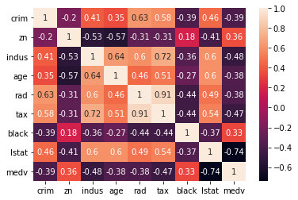

```python
# визуализируем коэффициенты корреляции
sns.heatmap(data1.corr(),annot=True)
```